# Puppy Small Dog Analysis

#### >> Q81

**We’d like to learn more about your puppy’s mother.**

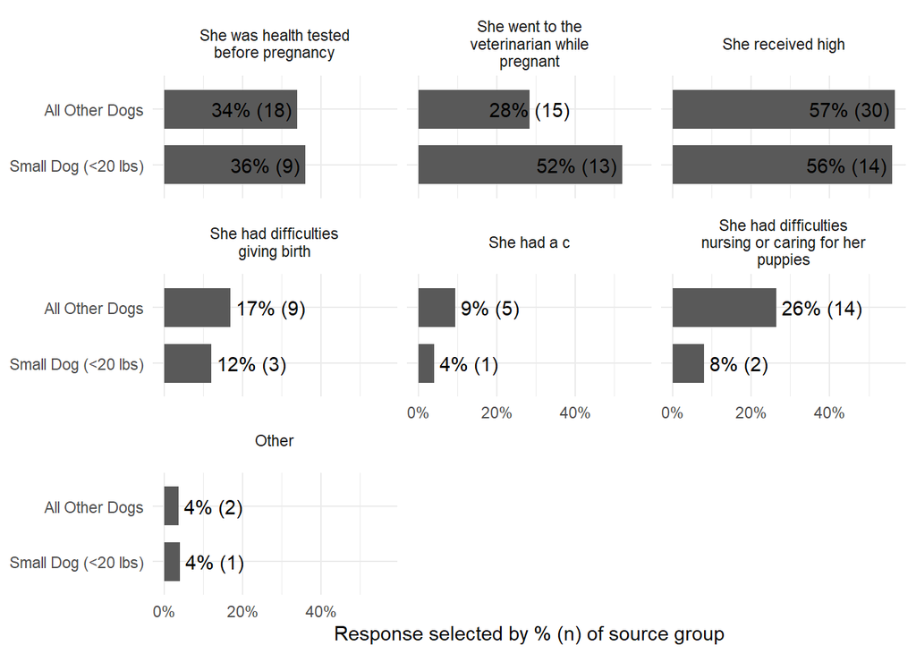

#### >> Q82

**Q82: We are interested to learn more about puppy socialization. If you socialized the puppies, please briefly describe how you did so. Please write “N/A” if you did not socialize them.**

12 non-empty/NA responses out of 25 possible responses ( 48 %) Showing only responses for the typology group

| Response |
| --- |
| We did not separate them and allowed them to play with each other. For human contact, they were introduced to children when they were around 6-8 weeks old and had always been around adults. They were … |
| They socialized with our other dogs and with us. |
| We had a good bond with all of puppies. We took care of them played with them and when it was time we gave them to lovings families that would love them as much as we did |
| I held the puppies every day and had neighbors and family over to hold them |
| Newborns only cc 2xwks old |
| During a basket in my living room with the mother a very large basket and when people come over that’s their socialization |
| They are not socialized outside of my home. |
| Yes |
| Shots deflie |
| Good luck with the rest today |
| Yeah I’m very so simple the dogs a lot of people are looking for some |
| Great quality |

#### >> Q83 (…)

**Q83: Did you plan for your puppy’s father to sire puppies?**

50 non-empty/NA responses out of 50 possible responses ( 100 %)

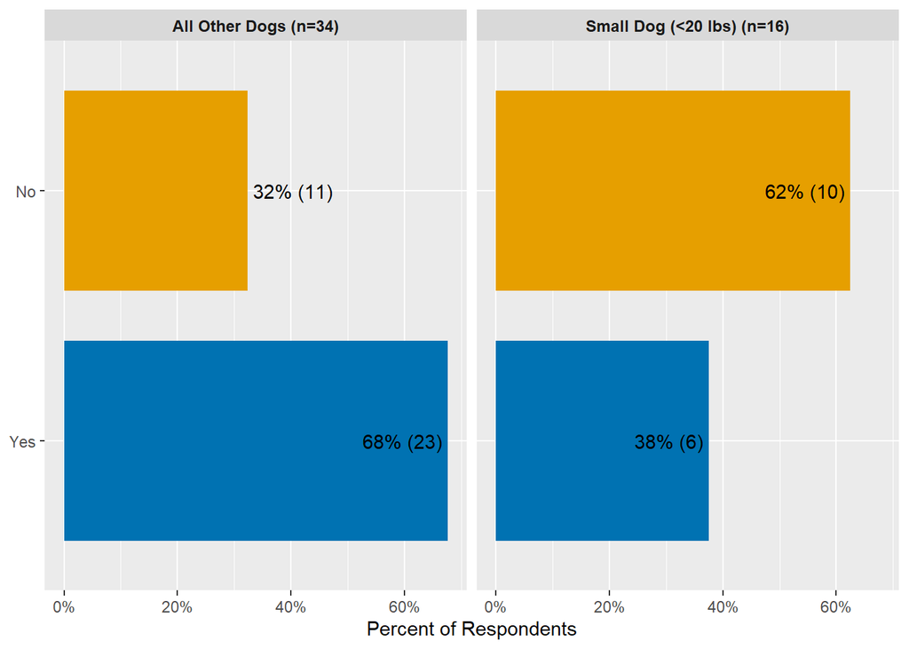

##### >>> Q84 (…)

**Why did you want him to sire puppies?**

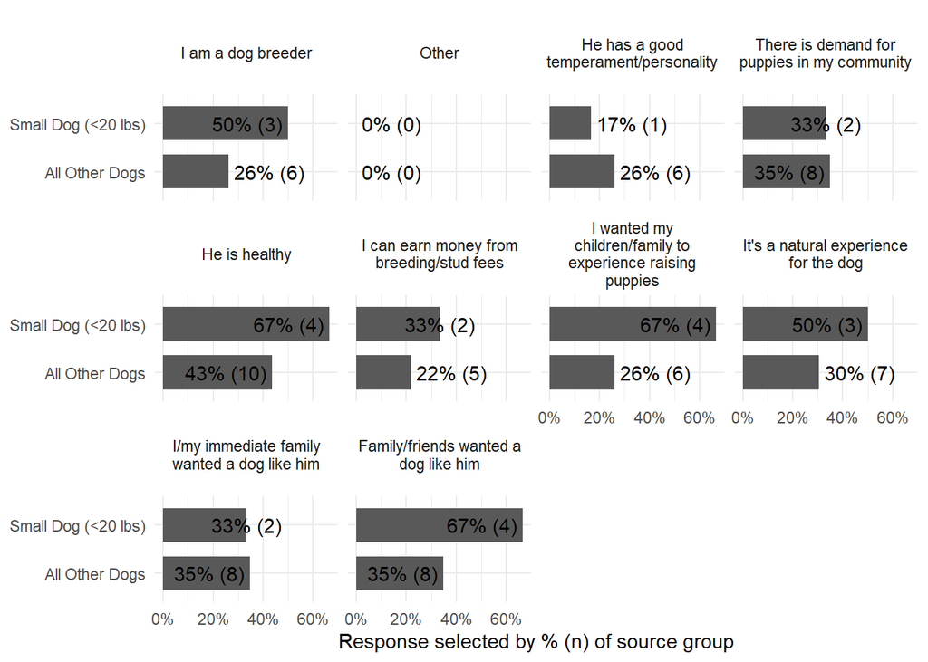

###### >>>> Q85

**Please select all that apply to your goals as a breeder:**

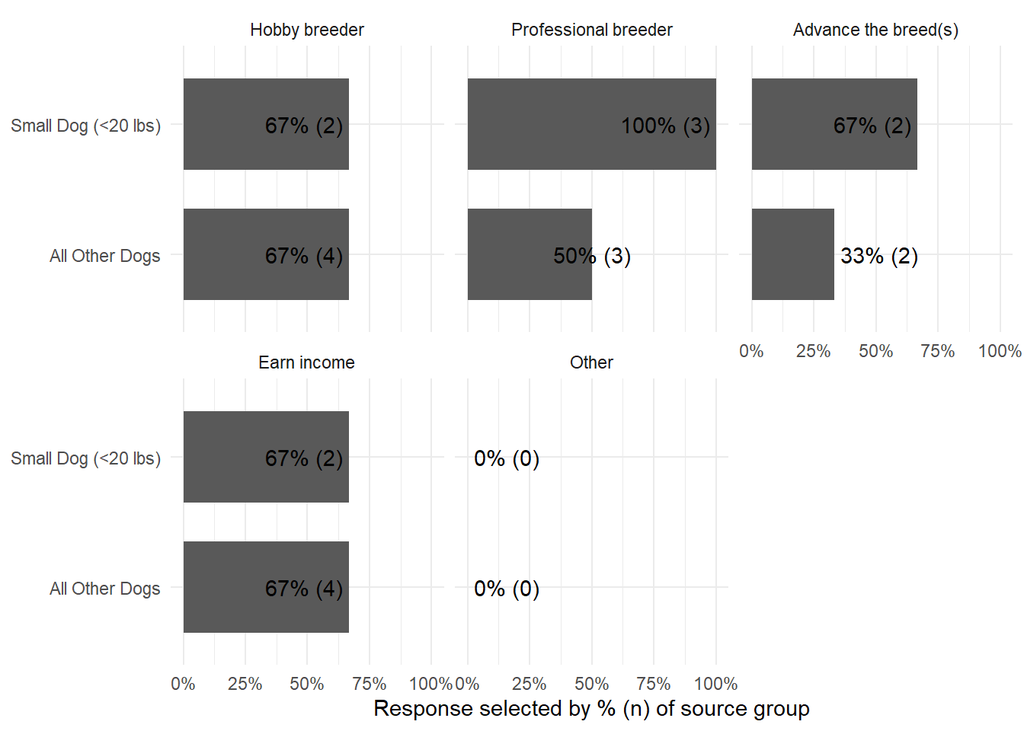

### > Source - market, auction, swap meet

### > Q86

**How did you find out about available puppies at the flea market, swap meet, or auction?**

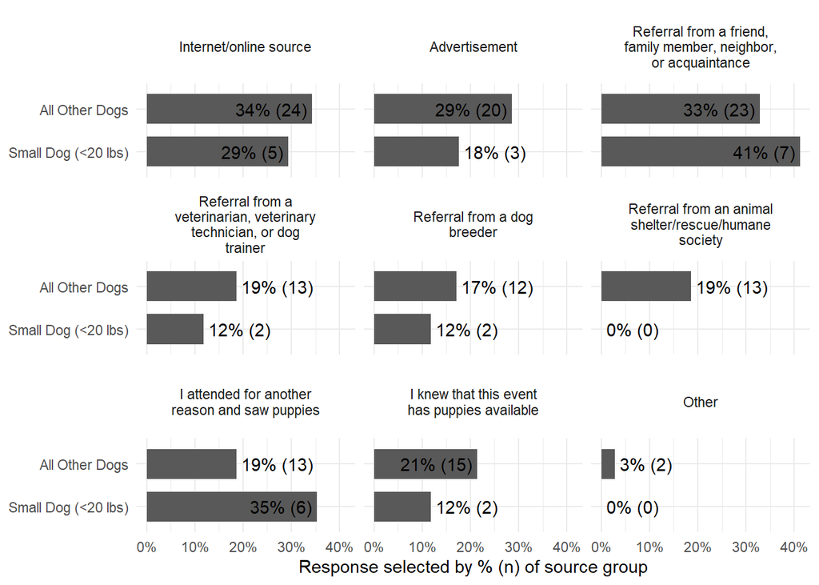

### > Q87

**Q87: Were other puppies from your puppy’s litter also for sale?**

87 non-empty/NA responses out of 87 possible responses ( 100 %)

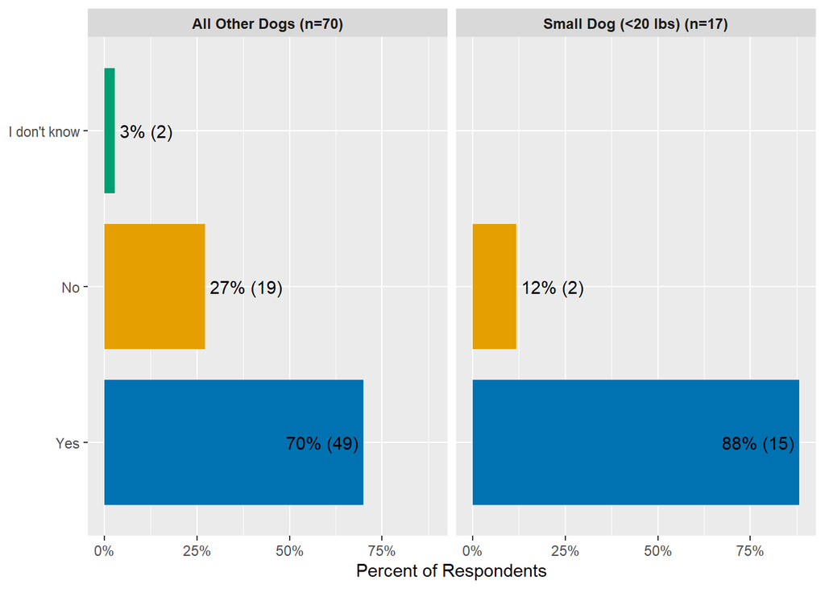

### > Q88

**Q88: How far did you travel to pick up your puppy?**

87 non-empty/NA responses out of 87 possible responses ( 100 %)

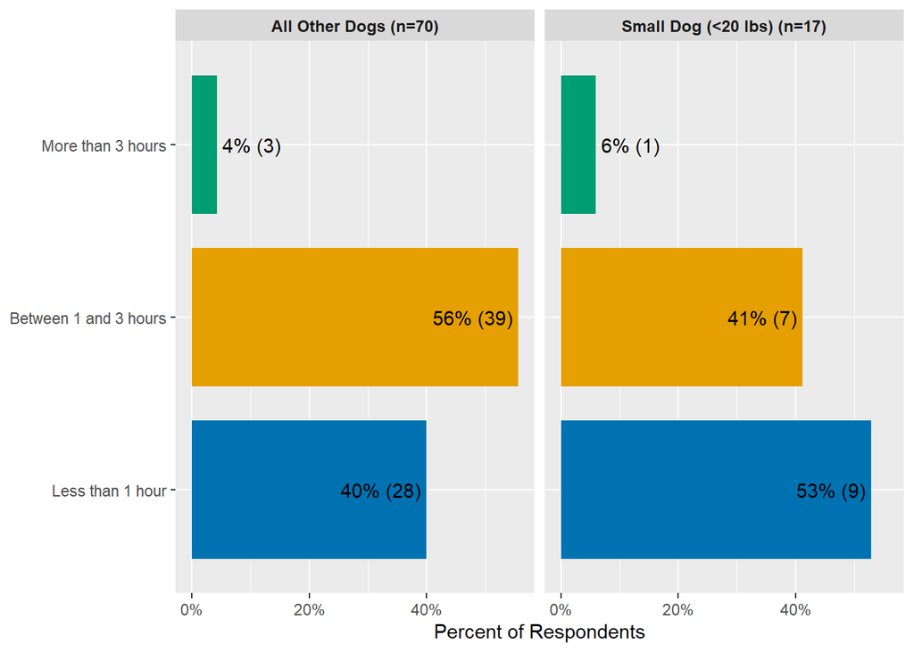

### > Source - market, auction, swap meet

### > Q89

**Q89: Please share where you got your puppy. We are particularly interested in the story of where the puppy was born and how it got to you, if you have this information.**

23 non-empty/NA responses out of 23 possible responses ( 100 %) Showing only responses for the typology group

| Response |
| --- |
| My daughter rescued a dog that ended up being pregnant and when they were born I feel in love with the puppy |
| Family friends who ate registered breeders |
| my puppy got from friends, and when I saw it, I immediately decided to have it on my own. |
| My aunt gave me her puppy as I was getting ready to lose my adult dog. She gave her to me for a time of comfort. |
| The puppy was a gift to me to replace a dog that had passed away |
| My grand daughter had a friend that had puppies they wanted to get rid of. |
| It was a gift |
| I got him from my grandma. Her dog had many puppies and sold them to family and others |
| My uncle bought it less than a year ago he moved to a no dog allowed place he gave it to me |
| I got her from an online website. They’re from Ohio and the puppy was driving to a near by pickup location 30 minutes from where I live. |
| Some dude online who was selling pups |
| From a couple who couldn’t keep him |
| My colleagues are rough collie savant two or three months old pure breed puppy |
| My friend Debbie gave me baby chihuahua |
| Puppy was advertised in Craig’s List. She is a Chi weenie. She is supposed to be registered but has no papers.We got her when she was 5 1/2 weeks old. Her teeth were so sharp, the mother stopped nursi… |
| My dog had puppies that’s where I got my puppy from |
| Craigslist pet |
| It was two days before Christmas when we were driving thru Hartford. At a stop light we noticed a dirty unkept very small puppy roaming around a dumpster. It was very cold Okie ands there was no owner… |
| I got it from a friend |
| Form a family friend |
| My puppy was a gift from my husband. She’s loving, playful and sweet! |
| It was a anniversary gift from my biyfriend |
| It was through our long distance family. They run a shelter and we decided to go and check it out 4 hours away and visit. Nothing was really what we wanted. The cuddles were nice. We went back to her … |

### > Source - NOT stray

### > Q90 (…)

**Q90: When you got your puppy, was there a policy for if you can no longer keep them?**

3708 non-empty/NA responses out of 3708 possible responses ( 100 %)

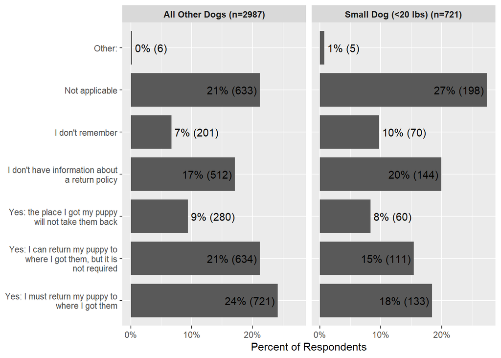

#### >> Q91

**Will you get a refund if you return your puppy?**

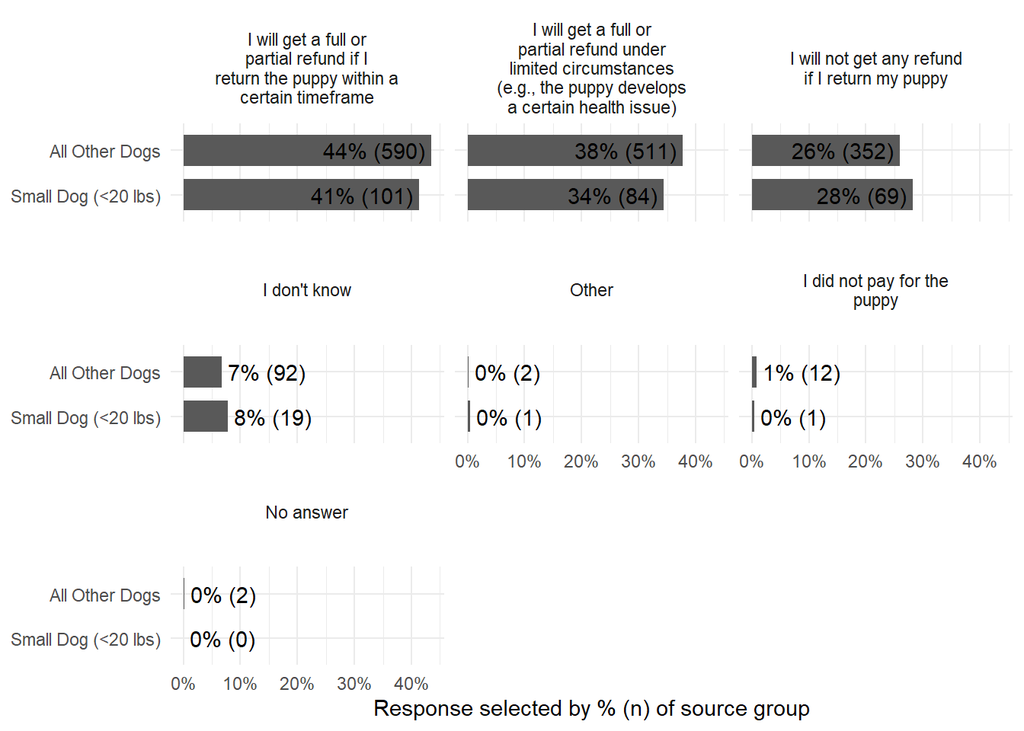

### > Q92 (…)

**Q92: Did your puppy come with a health guarantee?**

3708 non-empty/NA responses out of 3708 possible responses ( 100 %)

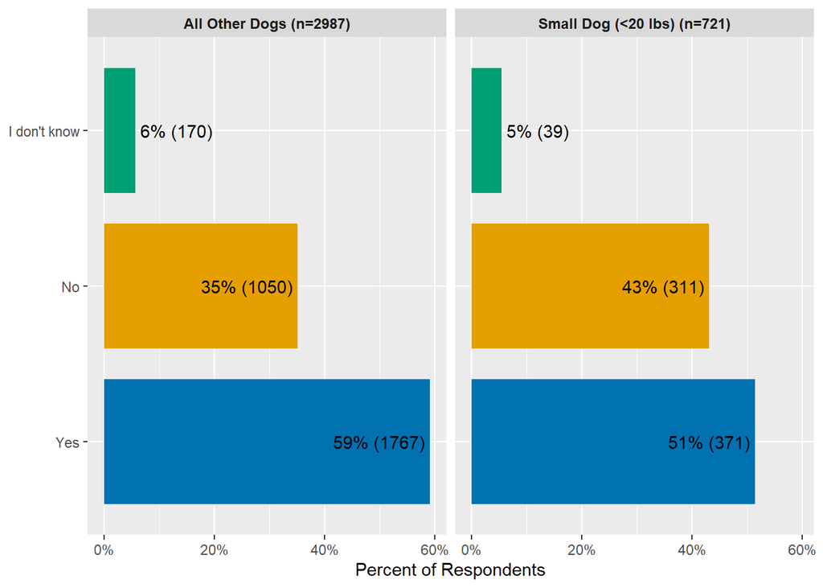

#### >> Q93

**Please select all that apply for your puppy’s health guarantee.**

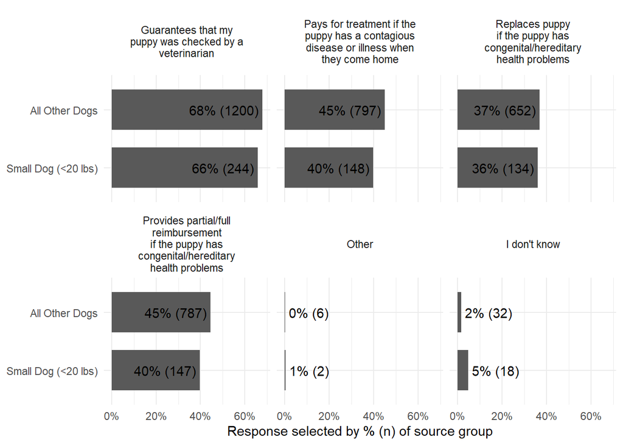

## Group B Only (…)

**Group B Only**

### > Q94

**Q94: Overall, how satisfied are you with your new puppy?**

2001 non-empty/NA responses out of 2001 possible responses ( 100 %)

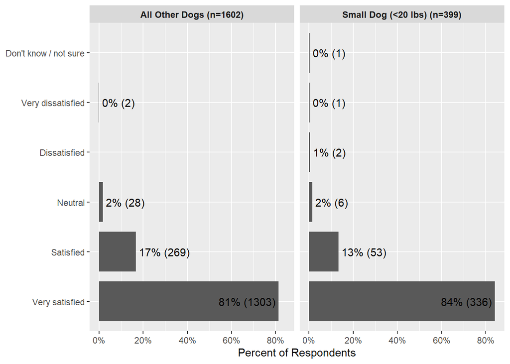

### > Q95 (…)

**Q95: How would you describe your puppy’s overall health?**

2001 non-empty/NA responses out of 2001 possible responses ( 100 %)

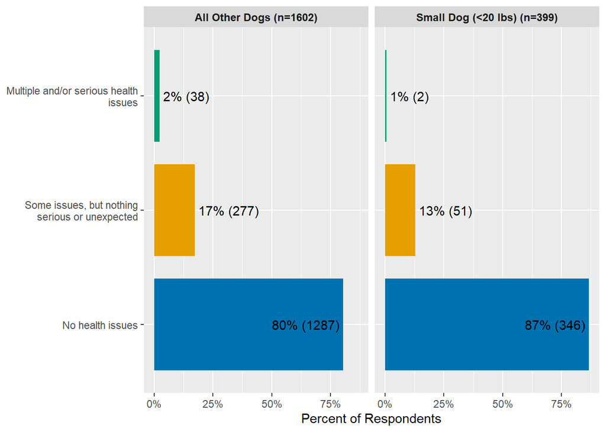

#### >> Q96

**What health challenges has your puppy experienced?**

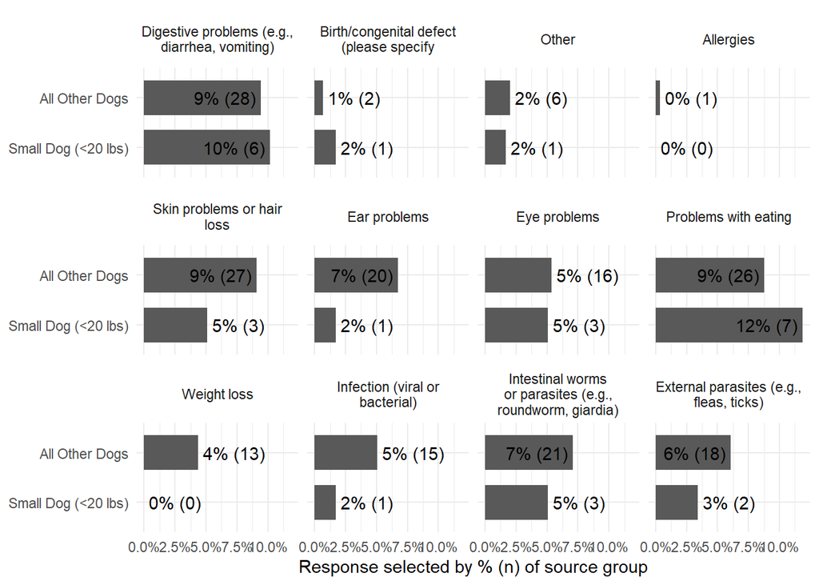

### > Q97 (…)

**Q97: How would you describe your puppy’s overall behavior?**

2001 non-empty/NA responses out of 2001 possible responses ( 100 %)

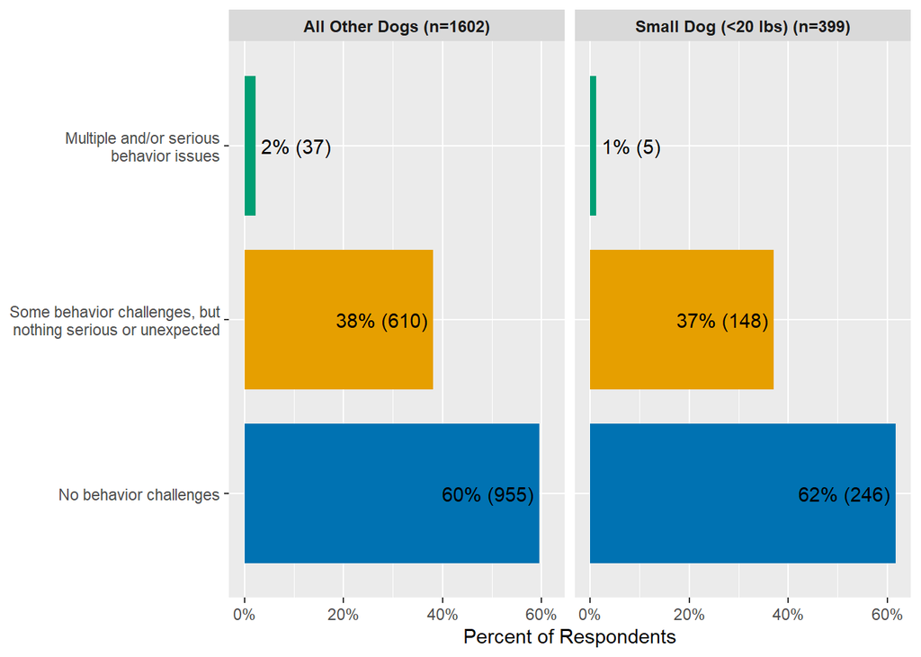

#### >> Q98

**What behavior challenges has your puppy experienced?**

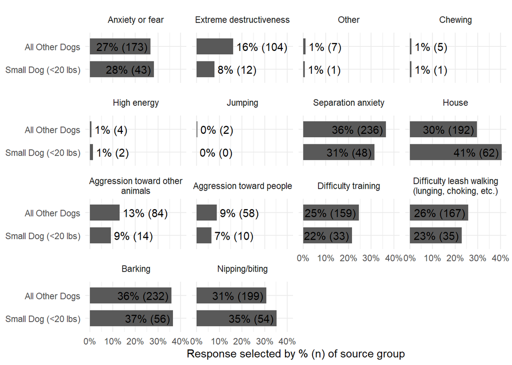

### > Q99

**Have you had challenges or concerns about any of the following?**

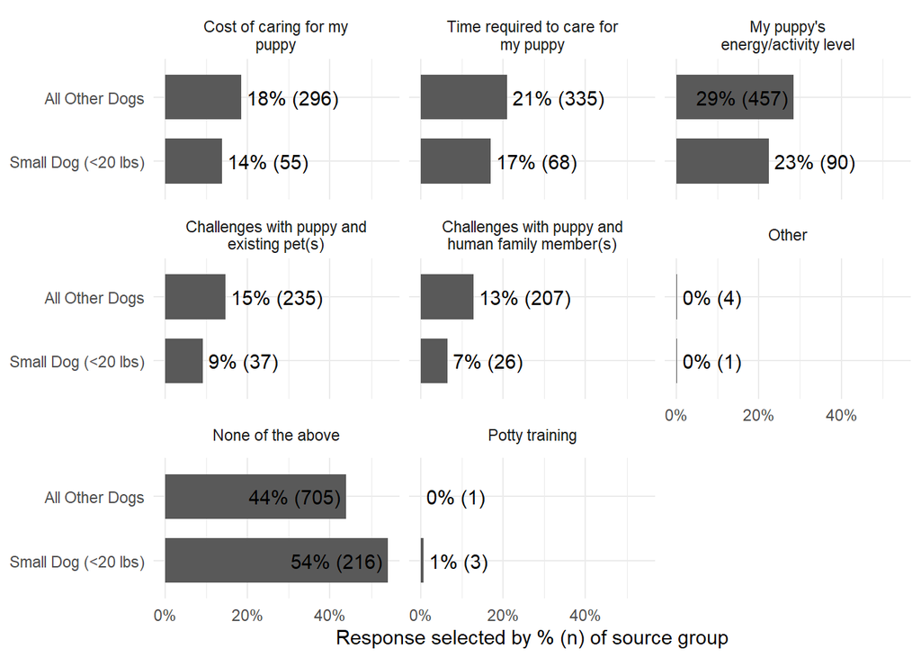

### > Q100 (…)

**Q100: Have you ever considered finding your dog a different home, for any reason? (This does not mean that you did so, just that you considered it.)**

2001 non-empty/NA responses out of 2001 possible responses ( 100 %)

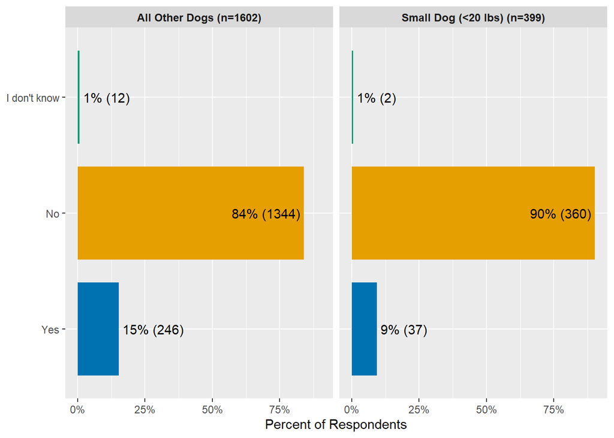

#### >> Q101

**Which of the following are or were causing to you consider rehoming your dog?**

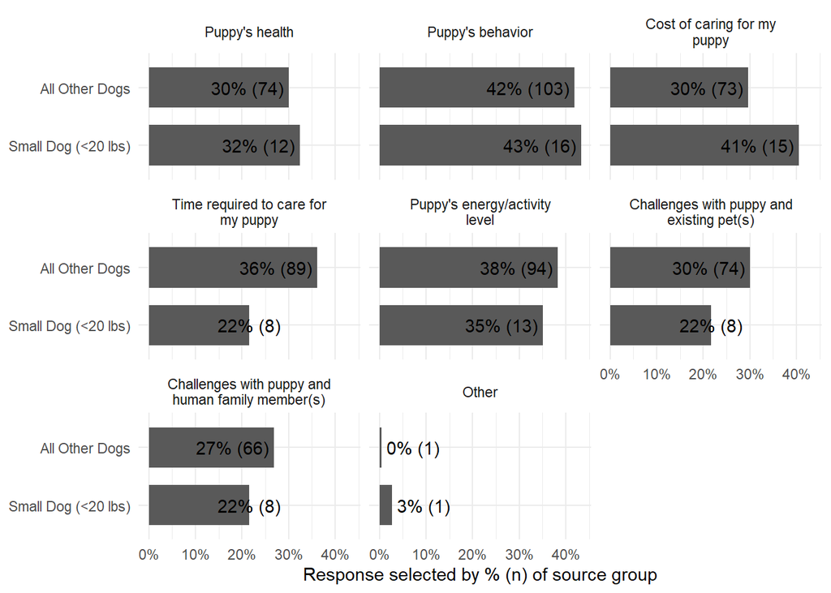

## Demographic Questions

## Q102a

**Q102a: Which state do you live in?**

Showing data for Typology breeds only

| Response | Count | Percent |
| --- | --- | --- |
| California | 112 | 14% |
| Texas | 72 | 9% |
| Florida | 56 | 7% |
| New York | 41 | 5% |
| Pennsylvania | 36 | 5% |
| Illinois | 32 | 4% |
| Ohio | 31 | 4% |
| Georgia | 25 | 3% |
| Michigan | 23 | 3% |
| Wisconsin | 21 | 3% |
| Arizona | 20 | 3% |
| Virginia | 20 | 3% |
| Tennessee | 19 | 2% |
| Missouri | 18 | 2% |
| Indiana | 17 | 2% |
| New Jersey | 17 | 2% |
| South Carolina | 16 | 2% |
| Arkansas | 15 | 2% |
| Nevada | 15 | 2% |
| North Carolina | 14 | 2% |
| Louisiana | 13 | 2% |
| Colorado | 12 | 2% |
| Alabama | 11 | 1% |
| Mississippi | 11 | 1% |
| Maryland | 10 | 1% |
| Massachusetts | 10 | 1% |
| Washington | 10 | 1% |
| Kentucky | 9 | 1% |
| Minnesota | 8 | 1% |
| Nebraska | 8 | 1% |
| Oregon | 8 | 1% |
| Iowa | 7 | 1% |
| New Mexico | 7 | 1% |
| Oklahoma | 7 | 1% |
| Connecticut | 6 | 1% |
| Kansas | 6 | 1% |
| West Virginia | 6 | 1% |
| Utah | 5 | 1% |
| Rhode Island | 4 | 1% |
| Hawaii | 3 | 0% |
| Montana | 3 | 0% |
| Maine | 2 | 0% |
| Delaware | 1 | 0% |
| Idaho | 1 | 0% |
| New Hampshire | 1 | 0% |
| North Dakota | 1 | 0% |
| South Dakota | 1 | 0% |
| Wyoming | 1 | 0% |

## Q102b

**Q102b: What is the zip code where you live?**

Showing data for Typology breeds only

| Response | Count | Percent |
| --- | --- | --- |
| 40701 | 3 | 0% |
| 77449 | 3 | 0% |
| 88061 | 2 | 0% |
| 92376 | 2 | 0% |
| 08021 | 2 | 0% |
| 60651 | 2 | 0% |
| 17046 | 2 | 0% |
| 89147 | 2 | 0% |
| 74133 | 2 | 0% |
| 92335 | 2 | 0% |
| 93535 | 2 | 0% |
| 90001 | 2 | 0% |
| 60451 | 2 | 0% |
| 92101 | 2 | 0% |
| 68164 | 2 | 0% |
| 10704 | 2 | 0% |
| 11361 | 2 | 0% |
| 33774 | 2 | 0% |
| 78242 | 2 | 0% |
| 94590 | 2 | 0% |
| 88130 | 2 | 0% |
| 75149 | 2 | 0% |
| 63135 | 2 | 0% |
| 89104 | 2 | 0% |
| 11373 | 2 | 0% |
| 29650 | 2 | 0% |
| 89081 | 2 | 0% |
| 30341 | 2 | 0% |
| 84075 | 2 | 0% |
| 29835 | 2 | 0% |

[output cut: 713 more lines]

## Q103

**Q103: What is your gender?**

4002 non-empty/NA responses out of 4002 possible responses ( 100 %)

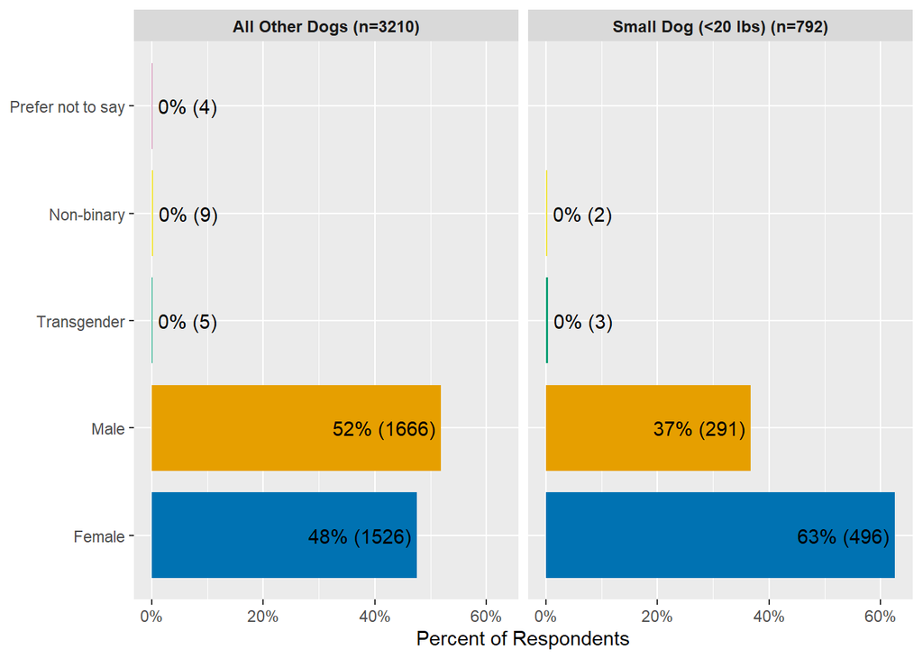

## Q104

**Q104: What is the highest level of school you completed?**

4002 non-empty/NA responses out of 4002 possible responses ( 100 %)

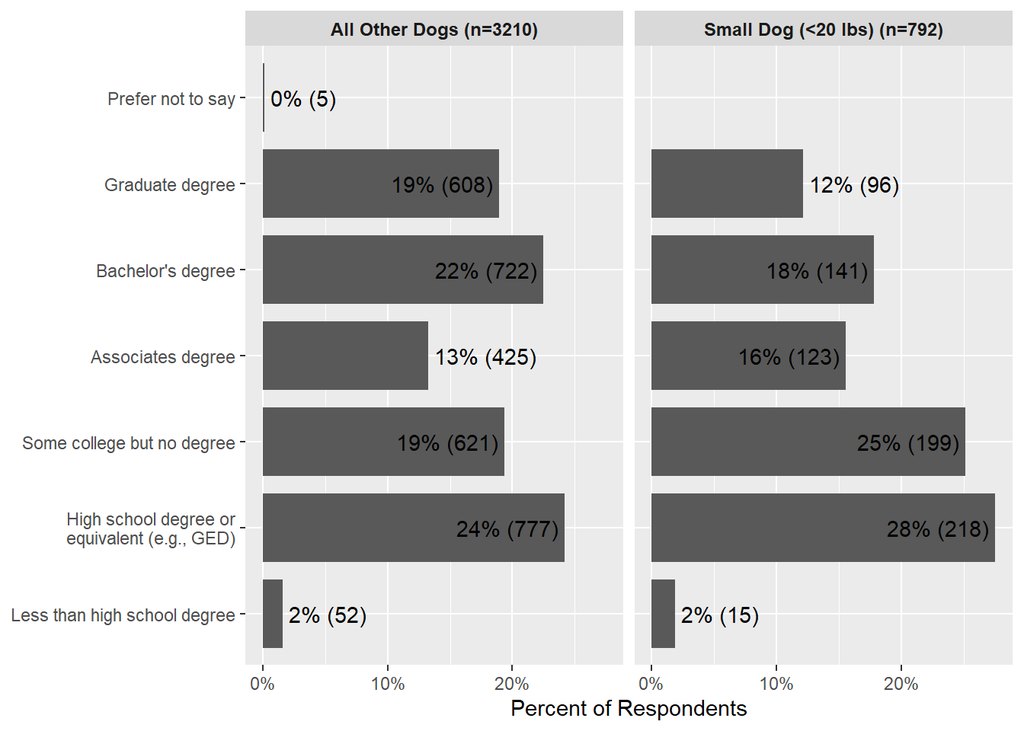

## Q105

**Q105: What is your total annual household income?**

4002 non-empty/NA responses out of 4002 possible responses ( 100 %)

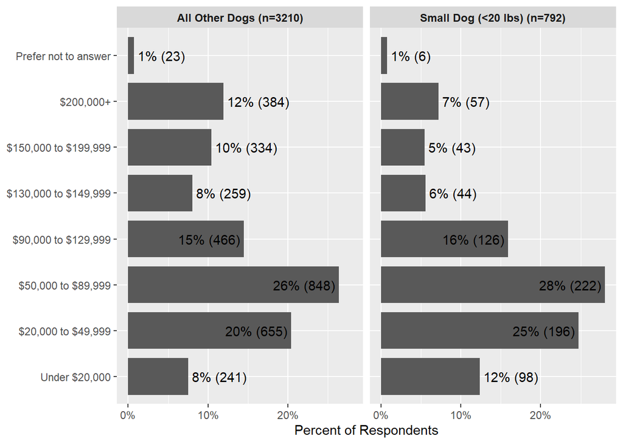

## Q106

**Q106: Are you of Hispanic, Latino, or Spanish origin?**

4002 non-empty/NA responses out of 4002 possible responses ( 100 %)

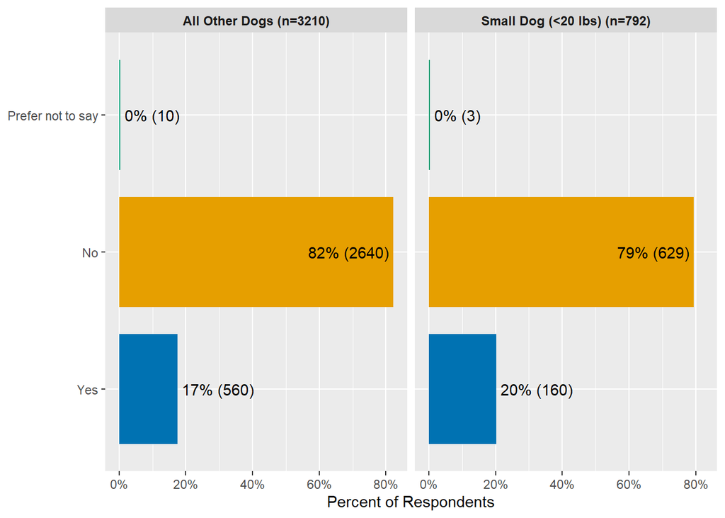

## Q107

**Q107: How would you describe yourself?**

4002 non-empty/NA responses out of 4002 possible responses ( 100 %)

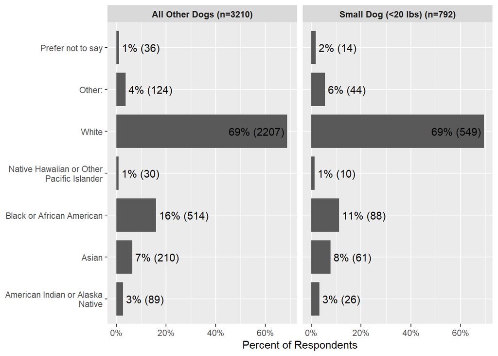

## Q108

**Q108: Do you own or rent your home?**

4002 non-empty/NA responses out of 4002 possible responses ( 100 %)

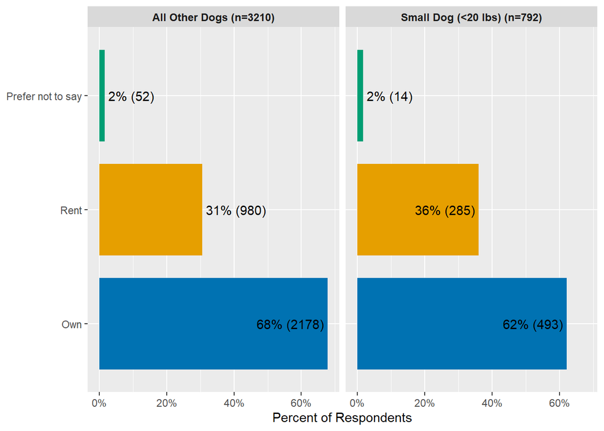